# STAT501_L2_SLR_Model_Evaluation

Ada Lazuli

2025-10-25

```r
library(dplyr)
library(ggplot2)
library(qqplotr)
library(tidyr)
library(reactable)
library(openxlsx)
```

# Lesson Overview

This lesson presents two alternative methods for testing whether a linear association exists between the predictor x and the response y in a simple linear regression model:

$H_0: \beta_1 = 0 \text{ versus } H_a: \beta_1 \neq 0$

One is the t-test for the slope while the other is an analysis of variance (ANOVA) F-test.

As you know, one of the primary goals of this course is to be able to translate a research question into a statistical procedure. Here are two examples of research questions and the alternative statistical procedures that could be used to answer them:

1. Is there a (linear) relationship between skin cancer mortality and latitude?
   - What statistical procedure answers this research question? We could estimate the regression line and then use the t-test to determine if the slope, , of the population regression line, is 0.
   - Alternatively, we could perform an (analysis of variance) F-test.
2. Is there a (linear) relationship between height and grade point average?
   - What statistical procedure answers this research question? We could estimate the regression line and then use the t-test to see if the slope, , of the population regression line, is 0.
   - Again, we could alternatively perform an (analysis of variance) F-test.

We also learn a way to check for linearity — the “L” in the “LINE” conditions — using the linear lack of fit test. This test requires replicates, that is multiple observations of y for at least one (preferably more) values of x, and concerns the following hypotheses:

$H_0$: There is no lack of linear fit.

$H_a$: There is a lack of linear fit.

# Example 2.11-The Lack Of Fit F-Test

```r
df <- read.table("./Data/STAT501_Lesson02/newaccounts.txt", header = T)
reactable(df,searchable = TRUE,sortable = TRUE,
          defaultPageSize = 5, bordered = TRUE, highlight = TRUE)
```

| Size | New | New2 |
| --- | --- | --- |
| 75 | 28 | 85 |
| 75 | 42 | 88 |
| 100 | 112 | 97 |
| 100 | 136 | 100 |
| 125 | 160 | 108 |
| 125 | 150 | 113 |
| 150 | 152 | 126 |
| 175 | 156 | 134 |
| 175 | 124 | 139 |
| 200 | 124 | 147 |

[output cut: 1 more lines]

This data consists of 11 observations that capture the minimum deposit size and the number of new accounts.

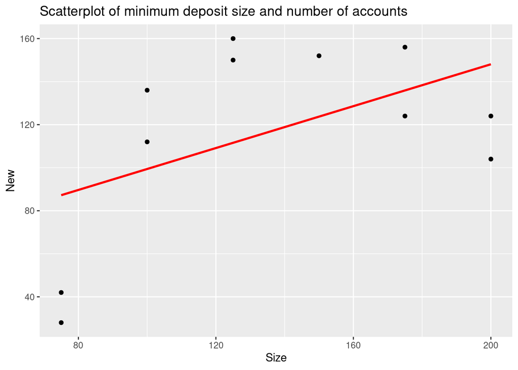

```r
ggplot(df, aes(x=Size, y=New)) + geom_point() +
  geom_smooth(method = "lm", se = FALSE, color ="red") +
  ggtitle("Scatterplot of minimum deposit size and number of accounts")
```

The data shows a poor linear relationship between the number of accounts and the minimum deposit size.

```r
model <- lm(New ~ Size, data=df)
summary(model)
```

```
##
## Call:
## lm(formula = New ~ Size, data = df)
##
## Residuals:
##    Min     1Q Median     3Q    Max
## -59.23 -34.06  12.61  32.44  48.44
##
## Coefficients:
##             Estimate Std. Error t value Pr(>|t|)
## (Intercept)  50.7225    39.3979   1.287     0.23
## Size          0.4867     0.2747   1.772     0.11
##
## Residual standard error: 40.47 on 9 degrees of freedom
## Multiple R-squared:  0.2586, Adjusted R-squared:  0.1762
## F-statistic: 3.139 on 1 and 9 DF,  p-value: 0.1102
```

```r
anova(model)
```

```
## Analysis of Variance Table
##
## Response: New
##           Df  Sum Sq Mean Sq F value Pr(>F)
## Size       1  5141.3  5141.3  3.1389 0.1102
## Residuals  9 14741.6  1638.0
```

For the lack of fit test in R

```r
model_full <- lm(New ~ factor(Size), data=df)
anova(model, model_full)
```

```
## Analysis of Variance Table
##
## Model 1: New ~ Size
## Model 2: New ~ factor(Size)
##   Res.Df   RSS Df Sum of Sq      F   Pr(>F)
## 1      9 14742
## 2      5  1148  4     13594 14.801 0.005594 **
## ---
## Signif. codes:  0 '***' 0.001 '**' 0.01 '*' 0.05 '.' 0.1 ' ' 1
```

### Lack Of Fit Test

For this lack of fit test, the hypotheses are:

$H_0$: The relationship assumed in the model is reasonable, i.e., there is no lack of fit.

$H_a$: The relationship assumed in the model is not reasonable, i.e., there is a lack of fit.

R gives use SSLF and SSPE, but it does not give MSLF and MSPE.

$$MSLF = \frac{SSLF}{c - 2}, \quad MSPE = \frac{SSPE}{n - c}$$
$c$ is just the number of factors. In this instance c is 6, as seen here:

```r
factor(df$Size)
```

```
##  [1] 75  75  100 100 125 125 150 175 175 200 200
## Levels: 75 100 125 150 175 200
```

So,
$$MSLF = \frac{SSLF}{c - 2} = \frac{14742 - 1148}{6 - 2}= 3398.5 ,\quad
MSPE = \frac{1148}{11-6} = 229.6$$

Since our p-value is less than our assumed $\alpha$ of $0.05$, we have evidence to reject the null hypothesis.

At a significance level of 5%, there is evidence that the relationship assumed in the model is not reasonable.

# Example 2-5: Highway Sign Reading Distance

The data consists of 30 observations that capture a driver’s age and the maximum distance (in feet) at which individuals can read a highway sign.

```r
df <- read.table("./Data/STAT501_Lesson02/signdist.txt", header = T)
reactable(df,searchable = TRUE,sortable = TRUE,
          defaultPageSize = 5, bordered = TRUE, highlight = TRUE)
```

| Age | Distance |
| --- | --- |
| 18 | 510 |
| 20 | 590 |
| 22 | 560 |
| 23 | 510 |
| 23 | 460 |
| 25 | 490 |
| 27 | 560 |
| 28 | 510 |
| 29 | 460 |
| 32 | 410 |

[output cut: 20 more lines]

There seems to be a negative linear relationship between the age of the drive and the distance that they can read the sign.

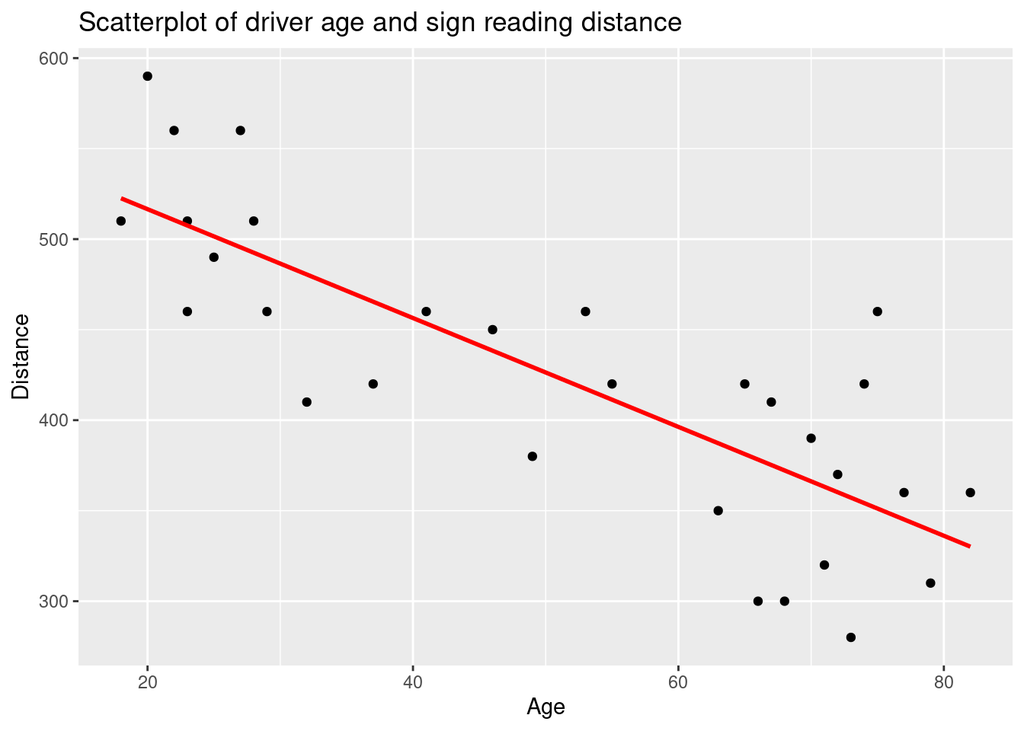

```r
ggplot(df, aes(x=Age, y=Distance)) + geom_point() +
  geom_smooth(method = "lm", se = FALSE, color ="red") +
  ggtitle("Scatterplot of driver age and sign reading distance")
```

```r
model <- lm(Distance ~ Age, data = df)
summary(model)
```

```
##
## Call:
## lm(formula = Distance ~ Age, data = df)
##
## Residuals:
##     Min      1Q  Median      3Q     Max
## -78.231 -41.710   7.646  33.552 108.831
##
## Coefficients:
##             Estimate Std. Error t value Pr(>|t|)
## (Intercept) 576.6819    23.4709  24.570  < 2e-16 ***
## Age          -3.0068     0.4243  -7.086 1.04e-07 ***
## ---
## Signif. codes:  0 '***' 0.001 '**' 0.01 '*' 0.05 '.' 0.1 ' ' 1
##
## Residual standard error: 49.76 on 28 degrees of freedom
## Multiple R-squared:  0.642,  Adjusted R-squared:  0.6292
## F-statistic: 50.21 on 1 and 28 DF,  p-value: 1.041e-07
```

```r
anova(model)
```

```
## Analysis of Variance Table
##
## Response: Distance
##           Df Sum Sq Mean Sq F value    Pr(>F)
## Age        1 124333  124333  50.211 1.041e-07 ***
## Residuals 28  69334    2476
## ---
## Signif. codes:  0 '***' 0.001 '**' 0.01 '*' 0.05 '.' 0.1 ' ' 1
```

### Hypothesis Test for the intercept ($\beta_0$)

The hypotheses for this test are:

$H_0: \beta_0 = 0\\H_a: \beta_0 \neq 0$

The test statistic is given by:

$$t^* = \frac{b - \beta_0}{se(b_0)} = \frac{576.6819}{23.4709} = 24.57$$

The degrees of freedom are $df = n - p = 30 - 2 = 28$

```r
alpha <- 0.05
2* (1 - pt(24.57, 28))
```

```
## [1] 0
```

Since $\text{p-value} \approx 0$, we have evidence to reject the null hypothesis.

At a significance level of 5%, there is evidence that the population intercept is not equal to 0.

### Hypothesis Tes for the Slope ($\beta_1$)

The hypotheses for this test are:

$H_0: \beta_1 = 0\\H_a: \beta_1 \neq 0$

The test statistic is given by:

$$t^* = \frac{b - \beta_1}{se(b_1)} = \frac{-3}{0.4243} = -7.086$$

```r
alpha <- 0.05
2* (1 - pt(abs(-7.086), 28))
```

```
## [1] 1.040877e-07
```

Since our p-value is less than our alpha of 0.05, there is evidence to reject the null hypothesis.

At a significance level of 5%, there is evidence that the population slope differs from zero.

### Confidence Interval for $\beta_1$

The confidence interval is given by:

$$\large \beta \pm t_{\frac{a}{2}, n - p} \times se(\beta_1)$$

Here, the confidence interval is:

```r
alpha <- 1 - 0.95 # for a 95% confidence interval.

t <- qt(1 - alpha/2, 28)
se <- 0.4243
b1 <- -3

sprintf("(%f, %f)", b1 - se*t, b1 + se*t)
```

```
## [1] "(-3.869139, -2.130861)"
```